# Statistical Graphics and Communication

Stefany Coxe

September 19, 2019

# Research question to plot

## Different questions = different visualizations

What is your research question? How can you answer it?

Different kinds of plots let you answer different questions and make different comparisons

One dataset, 25 visualizations:

https://flowingdata.com/2017/01/24/one-dataset-visualized-25-ways/

Same data, (roughly) same question, a bunch of different visualizations:

https://flowingdata.com/2018/10/17/ask-the-question-visualize-the-answer/

# Recap of ggplot2

## ggplot2

Based on the **grammar of graphics**

Dataset + variables to coordinate system + geometric object = plot

Geometric objects (“geoms”) are the key piece of the plot

Everything that goes into a plot (including the “ggplot()” part itself) is a *function*

- You can tell by the parentheses at the end
- Sometimes you add options (“arguments”) in the parentheses
- Sometimes you just have them at the end ()

## Basic ggplot template

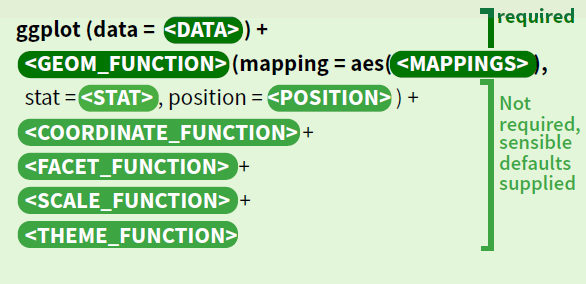

All screenshots from “Data Visualization” cheatsheet from Rstudio at: https://www.rstudio.com/resources/cheatsheets/

# Geom functions

## Geoms for 1 variable

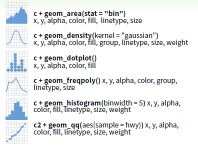

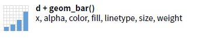

## Geoms for 2 variables: Continuous X and Y

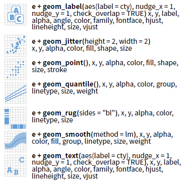

## Geoms for 2 variables: Discrete X, continuous Y

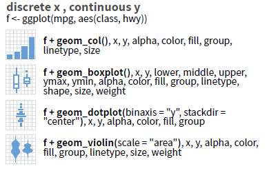

## Geoms for 2 variables: Discrete X and Y

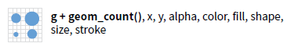

## Geoms for 2 variables: Continuous bivariate distribution

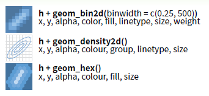

## Geoms for 2 variables: Continuous function

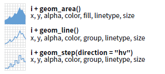

## Geoms for 2 variables: Error / variability

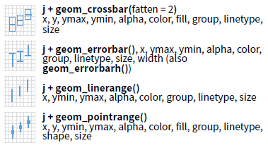

Four different ways to include error bars

- You must specify the min and max for the error bars

## Geoms for 3 variables

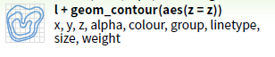

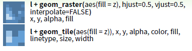

## Geom primitives

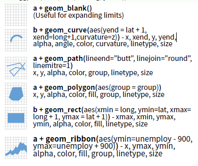

## Geom primitives

Line segments

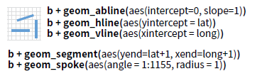

# Stat functions

## Statistical functions

Each geom has a default statistic associated with it

- e.g., geom_bar uses the “count” statistic

But you can explicitly change the statistic

- e.g., instead of the count (frequency) use a *proportion* that you’ve calculated and use the “identity” statistic with the proportion variable

# Position functions

## Position functions

How to arrange geoms that would otherwise overlap

Arguments in the geom_bar (and similar) geoms:

geom_bar(position = “dodge”)

- Move bars to be next to one another

geom_bar(position = “fill”)

- Fill up all vertical space with the bar, split appropriately between categories

geom_bar(position = “stack”)

- Stack the bars on top of one another, but don’t fill up the whole vertical space

## Position functions

This can replace geom_point

geom_jitter()

- Add random noise on both x and y axes to avoid overplotting
- Can be modified to only jitter on 1 or the other dimension:
  - geom_jitter(width = 0.5)
  - geom_jitter(height = 0.5)
- Or to limit how far the jitter spreads:
  - geom_jitter(width = 0.5, height = 0.5)

# Coordinate functions

## Coordinate system for the plot

coord_cartesian()

- default for most plots

coord_fixed(ratio = x/y)

- change aspect ratio between x and y (argument)

coord_flip()

- Make x into y and y into x

coord_polar()

- Polar coordinates

coord_trans(ytrans = “sqrt”)

- Transform one of the axes (argument), such as the y axis being square rooted

# Facet functions

## Faceting functions

There are a few faceting functions, but one does most of the things you will ever need: facet_grid()

facet_grid(cols = vars(X1))

- Can facet into columns based on a variable (here, X1)

facet_grid(rows = vars(X2))

- Can facet into rows based on a variable (here, X2)

facet_grid(rows = vars(X2), cols = vars(X1))

- Can facet into *both* rows and columns based on two variables

# Theme functions

## Theme functions

Themes are sets of changes to the overall look of the plot

- You just apply the theme and all the changes are made

You can use some built-in default themes (today), or use packaged themes that other people have made (soon) or even make your own theme (just for fun)

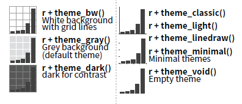

# Misc plots

## Miscellaneous plots (some with links)

**Stingray plot**

**Violin plot**

**Pirate ship plot**

**Packed bar chart**

**Slope graphs:**

[https://datascienceplus.com/creating-slopegraphs-with-r/ https://www.r-bloggers.com/more-on-slopegraphs/](https://datascienceplus.com/creating-slopegraphs-with-r/%20https://www.r-bloggers.com/more-on-slopegraphs/)

**Connected scatterplot – Healy chapter 8**

## Miscellaneous plots (some with links)

**Scatterplots plus:**

https://towardsdatascience.com/everything-you-need-to-know-about-scatter-plots-for-data-visualisation-924144c0bc5

**Spaghetti plots:**

https://stats.idre.ucla.edu/r/faq/how-can-i-make-spaghetti-plots/

**Proportions:**

https://flowingdata.com/2016/09/29/quickfire-how-to-for-visualizing-proportions-in-r/

## Miscellaneous plots (some with links)

**Waffle plots and swarm plots:**

https://paulvanderlaken.com/2019/01/25/visualization-innovation-waffleplots-and-swarmplots-aka-beeplots/amp/

https://www.r-bloggers.com/how-to-make-square-pie-charts-for-infographics-in-r/

**Raincloud plots:**

https://micahallen.org/2018/03/15/introducing-raincloud-plots/?fbclid=IwAR0ZJOzdYvk1baceGNxN-8E88-2RcUr5MQKDAgwylHf7jTjx5ilaD5UTqUI

**Radial plots:**

http://www.storytellingwithdata.com/blog/2019/6/28/swdchallenge-radial-data-viz

## Miscellaneous plots (some with links)

**Dot plot:**

https://www.r-bloggers.com/dotplot-the-single-most-useful-yet-largely-neglected-dataviz-type/

**Segmented column charts:**

https://www.r-bloggers.com/make-refreshing-segmented-column-charts-with-ggchicklet/

**Waterfall:**

https://junkcharts.typepad.com/junk_charts/2019/06/inspiration-from-a-waterfall-of-pie-charts-illustrating-hierarchies.html

https://www.r-bloggers.com/stacked-waterfall-graphs-in-r/

## Miscellaneous plots (some with links)

**Dumbbell plots:**

https://www.r-bloggers.com/make-multi-point-dumbbell-plots-in-ggplot2/

**Likert plots:**

https://www.r-bloggers.com/likert-plots-and-grouped-likert-plots-rstats/

**General links**

https://r4stats.com/examples/graphics-ggplot2/

http://r-statistics.co/Top50-Ggplot2-Visualizations-MasterList-R-Code.html

http://www.cookbook-r.com/Graphs/